# Exercise 3: Factor Analysis to Find Underlying Factors

**Course Instructor**: Dr. Suborna Ahmed

**Student Name**:

**Total Points**: 10

**Due**: check Canvas page for due date

**Submission**:

1. Write your code and answers in this RMD file
2. Knit your completed RMD file to WORD document
3. Check and upload your WORD document to Exercise 2 on Canvas

### Objectives

1. To become familiar with Factor Analysis as a tool used to uncover underlying relationships in a set of x-variables.
2. To learn how to use different rotations as a means of achieving the simple structure needed in order to be able to interpret the factors (and the factor scores) and assign meaningful names to each of them.

### General Description

Information was gathered by Tracy Hooper on bird abundancies, along with vegetation and other variables in a grassland area (a subset of her data is used in FRST 531 with her approval). Using factor analysis, the underlying relationships among **11 of the vegetation variables** was analyzed. The 11 variables are:

- `mayvgcov` and `mayvght` (% cover and height of vegetation in May)
- `junvgcov and`junvght` (% cover and height of vegetation in June);
- and horizontal cover variables, specifically: `baregrnd`, `bryopht`, `forbs`, `grass`, `rocks`, `shrubs`, and `trees` all as **percents**.

The overall objective is to use factor analysis to **obtain a few indices to represent underlying factors, and to be able to give these underlying factors names**. These factors could give insights into the data (e.g., which plots gave high scores on Factor 1 versus low scores, and what does this mean ecologically?). Also, these factors could be used in a subsequent analysis to replace these 11 variables.

However, for the factors to have meaning and to be able to name the factors, a simple structure is needed. For example, if Factor 1 has high positive correlations with `mayvgcov` and `junvgcov` perhaps this factor is “summer vegetation cover”. However, if Factor 1 also has a moderately high positive correlation with `rocks`, what does this mean? Instead another rotation may provide a more interpretable and simple structure.

For this, you will use first do the PCA. Then, you will use factor analysis first with no rotation. Then, you will use orthogonal and oblique rotations to get a simple solution. Remember that oblique rotations are much harder to interpret since the factors are correlated (unless the correlation is very low?). Our preference is to find a simple structure using orthogonal rotations if possible.

### Process

1. For this analysis, the data have been provided as `TRABREV2.txt` along with R codes and questions as in this Rmd file.
2. You will need to run the R code and get the outputs from running the code. There are two things you will need to change:
- Change the working directory to the location of the data on your computer, if you have not done so already.
- Add in code for the 4th factor analysis run (object will be called `veg.fac4`) by cutting and pasting code for the other factor analysis runs and then modifying this for an equamax rotation. There are three other factor analysis runs before this one (i.e., `veg.fac1` to `veg.fac3`) and one after (i.e., `veg.fac5`) that are already in the code and there is a location where to put the 4th run for `veg.fac4`.
3. The outputs will include:
- The PCA on the 11 variables;
- The unrotated factor solution, using two factors (`veg.fac1`)
- Several rotated factor solutions (`veg.fac2`, `veg.fac3`, `veg.fac4` (you will put the code in), and `veg.fac5` (the only oblique rotation).
4. You will be answering a **8 questions** to guide you through the outputs and interpret the results. The questions are marked with **TODO** to help you quickly locate them using the search tool, since this Rmd file is quite long. As you answer the questions, paste in the relevant R outputs (and/or graphs) to support your answers.

### R CODES

#### Introduction

Data from an outside text file from birds in grasslands study by Tracy Hooper (subset of her data used by permission) is brought in to R from an outside space-delimited text file. Alternatively, you could bring the text file into EXCEL and save it as a `.csv` file. Using only a subset of the variables, the goal is to get a simple structure on a few factors in order to label and interpret these factors. These factors would then commonly be passed to another analysis. We would prefer to obtain a simple structure using orthogonal rotations, but sometimes this is not possible. The R code starts with PCA first to indicate the contribution of each principal component. Factor analysis (FA) then starts with two factors and no rotation, which is like the PCA solution as presented in the Factor analysis notes. Then, further rotations are used to try to get the simple structure, starting with orthogonal and then oblique rotations.

#### PART 1: Clean out all R objects before starting.

Then set the directory for the data (and any files saved) and read the data. We assign it to an R object called `vegdat`. Do a few checks on the data.

```r
rm(list = ls(all = TRUE))
```

Read the data from `TRABREV3.txt` into `vegdat`, set `header=T` to include the original column (header) names

```r
vegdat <- read.table("TRABREV3.txt", header = T)
```

We will check the dimension of the table. We should get *145* rows and *27* columns.

```r
dim(vegdat) # 145 plots (one per row) and 27 variables.
```

```
## [1] 145  27
```

Here we are just exploring a bit more about this data object

```r
# class(vegdat) # what type of object is it?
# str(vegdat)  # what is in the object?
names(vegdat)  # print out the column (i.e., variable) names
```

```
##  [1] "site"     "point"    "h"        "rank"     "hola"     "vesp"
##  [7] "star"     "weme"     "lbcu"     "brbl"     "tres"     "mobl"
## [13] "amcr"     "savs"     "mayvgcov" "mayvght"  "junvgcov" "junvght"
## [19] "baregrnd" "bryopht"  "feces"    "forbs"    "grass"    "litter"
## [25] "rocks"    "shrubs"   "trees"
```

```r
head(vegdat, 5)  # print out the first few lines of data
```

```
##   site point    h rank   hola  vesp  star  weme lbcu  brbl  tres  mobl  amcr
## 1  B_E B_E10 0.87    2  6.727 1.727 0.000 0.000    0 0.000 0.091 0.000 0.000
## 2  B_E B_E11 0.87    2  2.545 2.818 0.091 0.091    0 0.091 0.818 0.364 0.091
## 3  B_E B_E12 0.87    2 12.364 1.727 0.000 0.000    0 0.000 0.364 0.000 0.000
## 4  B_E B_E13 0.87    2  6.455 1.727 0.091 0.000    0 0.273 0.091 0.182 0.000
## 5  B_E B_E14 0.87    2  2.091 3.455 0.273 0.000    0 0.636 3.364 0.000 0.000
##    savs mayvgcov mayvght junvgcov junvght baregrnd bryopht feces forbs grass
## 1 0.000     21.3     5.5     21.4     6.6    52.33   11.38   1.9 18.44 26.44
## 2 0.000     18.5     5.6     30.9     9.3    52.33   11.38   1.9 18.44 26.44
## 3 0.182     18.6     4.7     24.3     6.9    52.33   11.38   1.9 18.44 26.44
## 4 1.364     18.9     6.7     30.2     9.9    52.33   11.38   1.9 18.44 26.44
## 5 0.273     33.9     7.9     36.8     8.4    52.33   11.38   1.9 18.44 26.44
##   litter rocks shrubs trees
## 1   5.06  1.29   0.04     0
## 2   5.06  1.29   0.04     0
## 3   5.06  1.29   0.04     0
## 4   5.06  1.29   0.04     0
## 5   5.06  1.29   0.04     0
```

#### PART 2: Subset the variables for the FA into a different object

Variables that will make up `xdata` are: `mayvgcov`,`mayvght`, `junvgcov`,`junvght`,`baregrnd`,`bryopht`,`forbs`, `grass`, `rocks`, `shrubs`, and `trees`.

```r
xdata <- subset(vegdat,select = c(mayvgcov, mayvght, junvgcov, junvght,
     baregrnd, bryopht, forbs, grass,
     rocks, shrubs, trees))
```

Some simple checking of `xdata`. We should still get *145* rows, but this time only *11* columns.

```r
names(xdata)
```

```
##  [1] "mayvgcov" "mayvght"  "junvgcov" "junvght"  "baregrnd" "bryopht"
##  [7] "forbs"    "grass"    "rocks"    "shrubs"   "trees"
```

```r
class(xdata)
```

```
## [1] "data.frame"
```

```r
dim(xdata) # 145 rows and 11 columns
```

```
## [1] 145  11
```

#### PART 3: Basic stats and corelation matrix for the xdata

We will get basic stats using `stat.desc()` from the package `pastecs.` Make sure that you have downloaded the package. You can install it with `install.packages("pastecs")`. Uncomment the chunk below and run to see the summary of key statistics.

```r
# library(pastecs) # won't work if you have not installed the package first!!
# round(stat.desc(xdata), 2) # get some basic descriptive stats.
# summary(xdata)
```

Here is the correlation matrix rounded to the 2nd decimal place.

```r
round(cor(xdata), 2) # correlation matrix with elements rounded to 2 decimals
```

```
##          mayvgcov mayvght junvgcov junvght baregrnd bryopht forbs grass rocks
## mayvgcov     1.00    0.92     0.79    0.60    -0.42   -0.21 -0.21  0.28 -0.34
## mayvght      0.92    1.00     0.77    0.60    -0.41   -0.16 -0.25  0.31 -0.33
## junvgcov     0.79    0.77     1.00    0.88    -0.44   -0.17 -0.15  0.30 -0.36
## junvght      0.60    0.60     0.88    1.00    -0.38   -0.18 -0.09  0.24 -0.29
## baregrnd    -0.42   -0.41    -0.44   -0.38     1.00    0.12  0.03 -0.82  0.45
## bryopht     -0.21   -0.16    -0.17   -0.18     0.12    1.00  0.00  0.12 -0.03
## forbs       -0.21   -0.25    -0.15   -0.09     0.03    0.00  1.00 -0.41  0.06
## grass        0.28    0.31     0.30    0.24    -0.82    0.12 -0.41  1.00 -0.47
## rocks       -0.34   -0.33    -0.36   -0.29     0.45   -0.03  0.06 -0.47  1.00
## shrubs      -0.03    0.02     0.15    0.24     0.17   -0.07  0.08 -0.31 -0.10
## trees        0.32    0.31     0.23    0.23    -0.62   -0.28 -0.01  0.27 -0.02
##          shrubs trees
## mayvgcov  -0.03  0.32
## mayvght    0.02  0.31
## junvgcov   0.15  0.23
## junvght    0.24  0.23
## baregrnd   0.17 -0.62
## bryopht   -0.07 -0.28
## forbs      0.08 -0.01
## grass     -0.31  0.27
## rocks     -0.10 -0.02
## shrubs     1.00 -0.10
## trees     -0.10  1.00
```

#### PART 4: Perform PCA using `princomp()`

First, we do PCA to look at how many factors to keep to explain the majority of the variances of X variables. This is not strictly needed for Factor Analysis since you may set the number of factors based on what might be possible to interpret but still useful to justify the number of factors to be used.

**NOTE:** `cor` and `covar` in princomp( ) are not the same as `principal()` or `fa()` !!!

Here, `cor=TRUE` means using the correlation matrix (aka standardized X variables).

```r
veg.pca <- princomp(xdata, cor = TRUE)
```

Let’s get a summary with `summary()`

```r
summary(veg.pca, loadings = TRUE, cutoff = 0.0)
```

```
## Importance of components:
##                           Comp.1    Comp.2    Comp.3     Comp.4     Comp.5
## Standard deviation     2.0799375 1.3297756 1.1445450 1.04499320 0.91918117
## Proportion of Variance 0.3932854 0.1607548 0.1190894 0.09927371 0.07680855
## Cumulative Proportion  0.3932854 0.5540403 0.6731296 0.77240336 0.84921190
##                            Comp.6     Comp.7     Comp.8      Comp.9    Comp.10
## Standard deviation     0.82961958 0.72368504 0.52828268 0.304681144 0.24306923
## Proportion of Variance 0.06256988 0.04761091 0.02537114 0.008439145 0.00537115
## Cumulative Proportion  0.91178178 0.95939269 0.98476384 0.993202983 0.99857413
##                            Comp.11
## Standard deviation     0.125237914
## Proportion of Variance 0.001425867
## Cumulative Proportion  1.000000000
##
## Loadings:
##          Comp.1 Comp.2 Comp.3 Comp.4 Comp.5 Comp.6 Comp.7 Comp.8 Comp.9 Comp.10
## mayvgcov  0.411  0.176  0.021  0.215  0.244  0.156  0.322  0.155  0.337  0.644
## mayvght   0.409  0.168  0.056  0.220  0.204  0.071  0.366  0.267 -0.570 -0.414
## junvgcov  0.417  0.263  0.096  0.005  0.144 -0.072 -0.289 -0.080  0.587 -0.533
## junvght   0.367  0.299  0.063 -0.091  0.031 -0.223 -0.550 -0.318 -0.439  0.341
## baregrnd -0.354  0.379  0.210  0.294  0.064  0.104  0.086 -0.320 -0.095 -0.072
## bryopht  -0.107 -0.217  0.554 -0.162  0.481 -0.553  0.222 -0.118  0.028  0.031
## forbs    -0.130  0.167 -0.346 -0.638  0.535  0.159 -0.058  0.218 -0.068 -0.012
## grass     0.291 -0.531  0.170 -0.060 -0.172 -0.057 -0.218  0.347 -0.080  0.007
## rocks    -0.251  0.123 -0.333  0.476  0.187 -0.515 -0.265  0.460  0.028  0.036
## shrubs   -0.002  0.484  0.140 -0.381 -0.535 -0.371  0.263  0.311  0.048  0.038
## trees     0.234 -0.177 -0.594 -0.030 -0.066 -0.410  0.360 -0.453  0.011 -0.064
##          Comp.11
## mayvgcov  0.117
## mayvght  -0.067
## junvgcov  0.061
## junvght  -0.030
## baregrnd  0.680
## bryopht  -0.073
## forbs     0.246
## grass     0.627
## rocks     0.017
## shrubs    0.081
## trees     0.222
```

Interpretation of the `summary()` outputs:

- The first part shows the standard deviation (eigenvalues), how much each individual PC contribute to the variance, and the cumulative variance when you retain 1, 2, 3, … principal components
- The second part shows the “loadings”. This is in fact the **eigenvectors**. However, when we work with factor analysis later on with the function `principal()`, this will not be the case.

Get the correlation matrix for X variables and principal components. We do not need to scale the X variables since the correlation matrix already does that. Notice that the `loadings` obtain here is very different from the so called “loadings” above from `summary(veg.pca, loadings=TRUE,cutoff=0.0)`.

```r
loadings <- round(cor(xdata, veg.pca$scores), 7)
loadings
```

```
##              Comp.1     Comp.2     Comp.3     Comp.4     Comp.5     Comp.6
## mayvgcov  0.8548655  0.2345380  0.0235850  0.2245377  0.2242205  0.1290947
## mayvght   0.8507610  0.2238754  0.0637041  0.2302283  0.1875345  0.0586845
## junvgcov  0.8663447  0.3494392  0.1093699  0.0051789  0.1319592 -0.0596416
## junvght   0.7626013  0.3975007  0.0723825 -0.0946451  0.0282768 -0.1849919
## baregrnd -0.7363370  0.5042110  0.2401977  0.3067794  0.0587342  0.0864853
## bryopht  -0.2215855 -0.2887100  0.6344898 -0.1696341  0.4425232 -0.4586929
## forbs    -0.2700667  0.2222910 -0.3965831 -0.6670301  0.4916149  0.1316579
## grass     0.6055278 -0.7063544  0.1946949 -0.0629729 -0.1582150 -0.0473178
## rocks    -0.5220492  0.1629973 -0.3810171  0.4979017  0.1715128 -0.4270556
## shrubs   -0.0034724  0.6442433  0.1597679 -0.3986516 -0.4921007 -0.3078446
## trees     0.4857950 -0.2356071 -0.6797142 -0.0314748 -0.0605293 -0.3402702
##              Comp.7     Comp.8     Comp.9    Comp.10    Comp.11
## mayvgcov  0.2331034  0.0818026  0.1026016  0.1565678  0.0146173
## mayvght   0.2648114  0.1411173 -0.1737674 -0.1005158 -0.0084509
## junvgcov -0.2092235 -0.0421442  0.1787613 -0.1296744  0.0076459
## junvght  -0.3977908 -0.1678249 -0.1338940  0.0828845 -0.0037283
## baregrnd  0.0625741 -0.1689410 -0.0289210 -0.0174600  0.0851075
## bryopht   0.1607728 -0.0625162  0.0084313  0.0075707 -0.0091024
## forbs    -0.0417330  0.1152881 -0.0207296 -0.0030379  0.0308606
## grass    -0.1577337  0.1833388 -0.0243496  0.0017073  0.0785369
## rocks    -0.1917732  0.2430888  0.0084891  0.0087992  0.0021569
## shrubs    0.1903524  0.1640867  0.0145827  0.0091547  0.0101609
## trees     0.2604801 -0.2390922  0.0032192 -0.0156491  0.0277963
```

Let’s calculate the variances, percent variances, and cumulative percent variances and put these together using bind. round() these using d=2 (i.e., two decimal places)

```r
round(cbind("Variance" = veg.pca$sdev^2,
 "%" = 100*veg.pca$sdev^2 / sum(veg.pca$sdev^2),
  "Cumulative %" = 100 * cumsum(veg.pca$sdev^2) / sum(veg.pca$sdev^2)),
   d = 2)
```

```
##         Variance     % Cumulative %
## Comp.1      4.33 39.33        39.33
## Comp.2      1.77 16.08        55.40
## Comp.3      1.31 11.91        67.31
## Comp.4      1.09  9.93        77.24
## Comp.5      0.84  7.68        84.92
## Comp.6      0.69  6.26        91.18
## Comp.7      0.52  4.76        95.94
## Comp.8      0.28  2.54        98.48
## Comp.9      0.09  0.84        99.32
## Comp.10     0.06  0.54        99.86
## Comp.11     0.02  0.14       100.00
```

Check the sum of the variances to make sure they sum up to **11**, which is the number of X variables.

```r
sum(veg.pca$sdev^2) # check the sum of variances.
```

```
## [1] 11
```

Get a scree plot with `sdev^2` (that is the variance or eigenvalue) of each component.

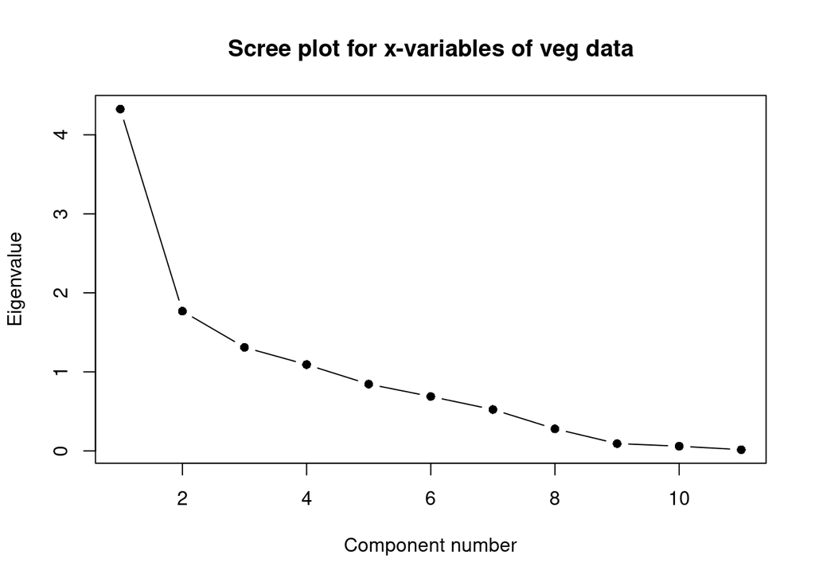

```r
plot(veg.pca$sdev^2, type = "b", pch = 16, xlab = "Component number",
ylab = "Eigenvalue", main = "Scree plot for x-variables of veg data")
```

Graph PC 1 and 2 (i.e., dimensions 1 and 2) with a biplot.

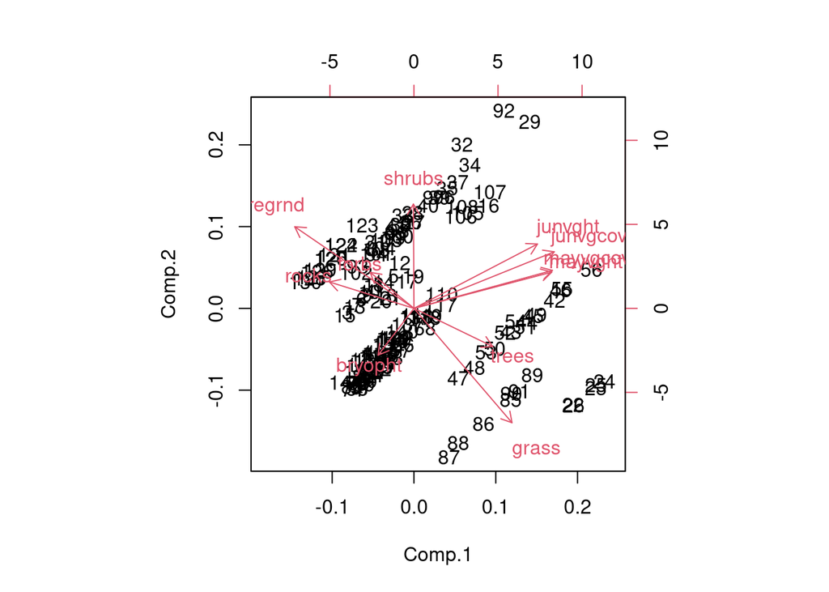

```r
biplot(veg.pca)
```

**OPTIONAL:** These are alternative graphics

```r
plot.new() # start a new plot
plot(loadings[, 1], loadings[, 2], axes = FALSE,
xlim = c(-1, 1), ylim = c(-1, 1), xlab = "", ylab = "")
mtext(expression("Comp.2"), 1, las = 0) # put this on axis 1 (x-axis)
mtext(expression("Comp.1"), 2, las = 0) # put this on axis 2 (y-axis)
axis(1, at = c(-1, 1), pos = 0) # axes labels at 0, from -1 to 1
axis(2, at = c(-1, 1), pos = 0) # axes labels at 0, from -1 to 1
# labels for the x variables to each correlation value, pos=4 is to the right.
text(loadings[, 1], loadings[, 2], labels = colnames(xdata), pos = 4, cex = 0.7)
```

[output not shown]

#### PART 5: Factor analysis using two factors based on PCA analysis.

##### General information:

The function `factanal()` can be used. Options for `rotation=` parameter are `"varimax"`, `"promax"`, and `"none"`.

The function principal() can be used.

Another alternative is the `psych` package and the function `fa()`. There are also options for getting the factor scores. `principal()` is used here from the `psych` package factor scores will be calculated using the default “regression” method.

To use the variety of rotations in `fa()` or in `principal()`, you also need the package `GPArotation` Rotations options:

- `"none"`, `"varimax"`, `"quartimax"`, `"bentlerT"`, `"equamax"`, `"varimin"`, `"geominT"` and `"bifactor"` are orthogonal rotations.
- `"promax"`, `"oblimin"`, `"simplimax"`,`"bentlerQ"`, `"geominQ"` and `"biquartimin"` and `"cluster"` are possible oblique transformations of the solution.

**NOTE:** `cor` and `covar` in `princomp()` are not the same as in `principal()` or `fa()`!!!

In `principal()` and in `fa()`, `cor="cor"` means **Pearson’s correlations** but then `covar=FALSE` means using the correlation matrix!!

For `veg.fac1`, no rotation used. For the following codes to work, please make sure you have downloaded the `psych` and `GPArotation` packages via `install.packages("GPArotation")` and `install.packages("psych")`.

```r
library(GPArotation)
library(psych)
veg.fac1 <- principal(xdata, nfactor = 2, rotate = "none",
      method = "regression", scores = TRUE, covar = FALSE, cor = "cor")
```

**NOTE:** `covar=FALSE` meaning using the correlation matrix. `cor="cor"` means using **Pearson’s correlations** (there are other options!)

We can explore this object and its components via the functions `class()` and `str()`. You can uncomment the codes to explore it by yourself by running this code chunk. We will not run it here at the meantime because the outputs are quite lengthy.

```r
# uncomment and run to see ouputs

# class(veg.fac1)   # what type of object is created?
# str(veg.fac1)     # what do we get?
```

```r
veg.fac1
```

```
## Principal Components Analysis
## Call: principal(r = xdata, nfactors = 2, rotate = "none", covar = FALSE,
##     scores = TRUE, method = "regression", cor = "cor")
## Standardized loadings (pattern matrix) based upon correlation matrix
##            PC1   PC2   h2   u2 com
## mayvgcov  0.85  0.23 0.79 0.21 1.1
## mayvght   0.85  0.22 0.77 0.23 1.1
## junvgcov  0.87  0.35 0.87 0.13 1.3
## junvght   0.76  0.40 0.74 0.26 1.5
## baregrnd -0.74  0.50 0.80 0.20 1.8
## bryopht  -0.22 -0.29 0.13 0.87 1.9
## forbs    -0.27  0.22 0.12 0.88 1.9
## grass     0.61 -0.71 0.87 0.13 2.0
## rocks    -0.52  0.16 0.30 0.70 1.2
## shrubs    0.00  0.64 0.42 0.58 1.0
## trees     0.49 -0.24 0.29 0.71 1.4
##
##                        PC1  PC2
## SS loadings           4.33 1.77
## Proportion Var        0.39 0.16
## Cumulative Var        0.39 0.55
## Proportion Explained  0.71 0.29
## Cumulative Proportion 0.71 1.00
##
## Mean item complexity =  1.5
## Test of the hypothesis that 2 components are sufficient.
##
## The root mean square of the residuals (RMSR) is  0.11
##  with the empirical chi square  197.46  with prob <  6.1e-25
##
## Fit based upon off diagonal values = 0.91
```

##### Let’s go over some important components of this object:

```r
veg.fac1$loadings
```

```
##
## Loadings:
##          PC1    PC2
## mayvgcov  0.855  0.235
## mayvght   0.851  0.224
## junvgcov  0.866  0.349
## junvght   0.763  0.398
## baregrnd -0.736  0.504
## bryopht  -0.222 -0.289
## forbs    -0.270  0.222
## grass     0.606 -0.706
## rocks    -0.522  0.163
## shrubs           0.644
## trees     0.486 -0.236
##
##                  PC1   PC2
## SS loadings    4.326 1.768
## Proportion Var 0.393 0.161
## Cumulative Var 0.393 0.554
```

`loadings` are simple **correlations between PC scores and x variables**, which is **NOT like using** `princomp()`! **Note:** very low correlations are not given and will appear missing.

```r
veg.fac1$weights
```

```
##                    PC1         PC2
## mayvgcov  0.1976046936  0.13263452
## mayvght   0.1966559308  0.12660467
## junvgcov  0.2002581492  0.19761270
## junvght   0.1762775359  0.22479215
## baregrnd -0.1702064700  0.28513832
## bryopht  -0.0512201448 -0.16326953
## forbs    -0.0624267255  0.12570867
## grass     0.1399695323 -0.39945324
## rocks    -0.1206732169  0.09217725
## shrubs   -0.0008026444  0.36432853
## trees     0.1122929570 -0.13323907
```

`weights` is the W (multipliers) to calculate factor scores

Next, we explore `communality` and `uniqueness`

```r
veg.fac1$communality # the h2 in the table
```

```
##  mayvgcov   mayvght  junvgcov   junvght  baregrnd   bryopht     forbs     grass
## 0.7858032 0.7739146 0.8726610 0.7395675 0.7964209 0.1324536 0.1223493 0.8656005
##     rocks    shrubs     trees
## 0.2991035 0.4150615 0.2915075
```

```r
veg.fac1$uniqueness  # the u2 in the table
```

```
##  mayvgcov   mayvght  junvgcov   junvght  baregrnd   bryopht     forbs     grass
## 0.2141968 0.2260854 0.1273390 0.2604325 0.2035791 0.8675464 0.8776507 0.1343995
##     rocks    shrubs     trees
## 0.7008965 0.5849385 0.7084925
```

We learned that the variance of each X variable is divided into **common variance (communality)** and **unique variance (uniqueness)**

- `communality` is the **common variance** of the X variables. It is the variance *accounted for by the Factors*. In other words, `communality` tells you what proportion of the variable’s variance is a result of either:
  - The principal components
  - The correlations between each variable and individual factors

It is calculated by squaring each factor loading and then adding them up for each X variable (sum of squared factor loadings)

- `uniqueness` is the **unique variance** of the X variables. It is, as its name implied, the variance *not accounted for by the Factors*, thus are *unique* to each X variable.

It is *1 - communality* since the correlation matrix was used. In other words, it is a measure of how well the regression estimate the factor scores using the x variables as inputs based on root mean square residuals. A smaller number means a better fit.

**Note:** `fit` is a measure of how well the factors represent the full correlation (or covariance matrix) of the X’s. A smaller value means a better fit.

```r
veg.fac1$Structure
```

```
##
## Loadings:
##          PC1    PC2
## mayvgcov  0.855  0.235
## mayvght   0.851  0.224
## junvgcov  0.866  0.349
## junvght   0.763  0.398
## baregrnd -0.736  0.504
## bryopht  -0.222 -0.289
## forbs    -0.270  0.222
## grass     0.606 -0.706
## rocks    -0.522  0.163
## shrubs           0.644
## trees     0.486 -0.236
##
##                  PC1   PC2
## SS loadings    4.326 1.768
## Proportion Var 0.393 0.161
## Cumulative Var 0.393 0.554
```

`Structure` is the Factor Structure matrix, which in this example represents the **simple correlations** between each X variable and each Factor. If the factors are **uncorrelated (orthogonal)** and **standardized**, or if is is an **orthogonal rotations of the axes**, the Factor Structure matrix and the Factor Pattern matrix is the same.

```r
veg.fac1$complexity
```

```
## mayvgcov  mayvght junvgcov  junvght baregrnd  bryopht    forbs    grass
## 1.149695 1.137832 1.316990 1.506034 1.768762 1.874630 1.928708 1.954364
##    rocks   shrubs    trees
## 1.193135 1.000058 1.445773
```

`complexity` is the Hoffman’s index of complexity.

**Extra:** it represents the number of latent components needed to account for the observed variables. Whereas a perfect simple structure solution has a complexity of 1 in that each item would only load on one factor, a solution with evenly distributed items has a complexity greater than 1. [Link to source](https://easystats.github.io/parameters/reference/model_parameters.principal.html#details)

Here, we calculate the **mean complexity** of the variables.

```r
mean(veg.fac1$complexity)
```

```
## [1] 1.479635
```

#### Correlations between the factors and the X variables

```r
round(cor(xdata, veg.fac1$scores), 2)
```

```
##            PC1   PC2
## mayvgcov  0.85  0.23
## mayvght   0.85  0.22
## junvgcov  0.87  0.35
## junvght   0.76  0.40
## baregrnd -0.74  0.50
## bryopht  -0.22 -0.29
## forbs    -0.27  0.22
## grass     0.61 -0.71
## rocks    -0.52  0.16
## shrubs    0.00  0.64
## trees     0.49 -0.24
```

This is same as `veg.fac1$loadings`. Smaller correlations are not shown.

##### Correlations between the two factors

```r
round(cor(veg.fac1$scores, veg.fac1$scores), 2)
```

```
##     PC1 PC2
## PC1   1   0
## PC2   0   1
```

##### “Hand calculate” the scores using the weights coefficients.

Get the standardized xdata first

```r
Xscaled <- scale(xdata, center = TRUE, scale = TRUE)
head(Xscaled)
```

```
##     mayvgcov    mayvght    junvgcov    junvght  baregrnd   bryopht     forbs
## 1 -0.3322900 -0.5951245 -1.04146634 -0.9542482 0.8047313 0.4326561 0.6556685
## 2 -0.5515236 -0.5620658 -0.35797227 -0.4017337 0.8047313 0.4326561 0.6556685
## 3 -0.5436938 -0.8595939 -0.83282078 -0.8928577 0.8047313 0.4326561 0.6556685
## 4 -0.5202045 -0.1984204 -0.40833499 -0.2789528 0.8047313 0.4326561 0.6556685
## 5  0.6542609  0.1982836  0.06651352 -0.5859052 0.8047313 0.4326561 0.6556685
## 6 -0.3792686 -0.7273592 -0.32199890 -0.6472957 0.8047313 0.4326561 0.6556685
##        grass     rocks     shrubs      trees
## 1 -0.9440149 0.1873652 -0.4841236 -0.1883294
## 2 -0.9440149 0.1873652 -0.4841236 -0.1883294
## 3 -0.9440149 0.1873652 -0.4841236 -0.1883294
## 4 -0.9440149 0.1873652 -0.4841236 -0.1883294
## 5 -0.9440149 0.1873652 -0.4841236 -0.1883294
## 6 -0.9440149 0.1873652 -0.4841236 -0.1883294
```

Check the dimension of the `weights` matrix

```r
dim(veg.fac1$weights)
```

```
## [1] 11  2
```

```r
myscores <- Xscaled %*% veg.fac1$weights
head(myscores)
```

```
##          PC1         PC2
## 1 -0.9350367 -0.05541636
## 2 -0.7375859  0.17895911
## 3 -0.9762158 -0.06190775
## 4 -0.6483261  0.24680019
## 5 -0.2972486  0.47763503
## 6 -0.7721366  0.13278753
```

```r
head(veg.fac1$scores)
```

```
##          PC1         PC2
## 1 -0.9350367 -0.05541636
## 2 -0.7375859  0.17895911
## 3 -0.9762158 -0.06190775
## 4 -0.6483261  0.24680019
## 5 -0.2972486  0.47763503
## 6 -0.7721366  0.13278753
```

Calculating communality and uniqueness for the PC orthogonal rotation and for other orthogonal rotations. Using the correlation matrix, the total variance of the X’s is 11 (=1 for each X since this is like you are using standardized x’s) can calculate the variances accounted for by squaring and adding the loadings.

##### Using just PC1, you get the variance of all X’s accounted for by PC1 only.

```r
PC1 <- veg.fac1$loadings[1:11, 1] # column 1
PC1
```

```
##     mayvgcov      mayvght     junvgcov      junvght     baregrnd      bryopht
##  0.854865529  0.850761049  0.866344749  0.762601264 -0.736336984 -0.221585507
##        forbs        grass        rocks       shrubs        trees
## -0.270066742  0.605527764 -0.522049206 -0.003472352  0.485795030
```

```r
sum(PC1^2)
```

```
## [1] 4.32614
```

Here, PC1 accounts for 4.32614 of the 11 x-variables variances , which is its `communality`.

##### Using PC2, you get the variance of all X’s accounte by PC2 only

```r
PC2 <- veg.fac1$loadings[1:11, 2] # column 2.
PC2
```

```
##   mayvgcov    mayvght   junvgcov    junvght   baregrnd    bryopht      forbs
##  0.2345380  0.2238754  0.3494392  0.3975007  0.5042110 -0.2887100  0.2222910
##      grass      rocks     shrubs      trees
## -0.7063544  0.1629973  0.6442433 -0.2356071
```

```r
sum(PC2^2)
```

```
## [1] 1.768303
```

Again, PC2 accounts for 1.7683 of the 11 x-variables variances.

If you add PC1 and PC2 as the only two factors retained, you get the total communality, all x’s and all factors. Total uniqueness not accounted for by these two components is the number of x-variables minus total communality. This is because the correlation matrix was used and, the sum of correlation is 11 (diagonal entries of correlation matrix)

The total communality is:

```r
sum(PC1^2) + sum(PC2^2)
```

```
## [1] 6.094443
```

Thus, the uniqueness is:

```r
11 - (sum(PC1^2) + sum(PC2^2))
```

```
## [1] 4.905557
```

##### Then, how much communality of each X variable versus uniqueness?

```r
commonbyX <- PC1^2 + PC2^2
commonbyX
```

```
##  mayvgcov   mayvght  junvgcov   junvght  baregrnd   bryopht     forbs     grass
## 0.7858032 0.7739146 0.8726610 0.7395675 0.7964209 0.1324536 0.1223493 0.8656005
##     rocks    shrubs     trees
## 0.2991035 0.4150615 0.2915075
```

You may notice that `commonbyX` is same as `h2` column in the `veg.fac1` summary of outputs. `h2` tells you how much each x-variable contribute to the common variance (`communality`). It should sum up to 6.0944, which is the total communality calculated with the principal components earlier. Let’s check:

```r
sum(commonbyX)
```

```
## [1] 6.094443
```

It’s the same number!

##### How much is unique for each variable?

```r
uniquebyX <- 1 - (PC1^2 + PC2^2)
uniquebyX
```

```
##  mayvgcov   mayvght  junvgcov   junvght  baregrnd   bryopht     forbs     grass
## 0.2141968 0.2260854 0.1273390 0.2604325 0.2035791 0.8675464 0.8776507 0.1343995
##     rocks    shrubs     trees
## 0.7008965 0.5849385 0.7084925
```

```r
sum(uniquebyX)
```

```
## [1] 4.905557
```

Similarly, you may notice that `uniquebyX` is similar to `u2` from the `veg.fac1` summary of outputs. This corresponds to the uniqueness of the x-variables. Again, it should sum up to 4.9055, which is the value of uniqueness calculated with the principal components earlier.

And finally, `commonbyX` and `uniquebyX` should sum up to 11, which is the number of x variables, similar to the result we have above.

```r
sum(commonbyX) + sum(uniquebyX)
```

```
## [1] 11
```

#### `Varimax` rotation: A further orthogonal rotation

We will called PCs as RC1 and RC2 now. Remember to install the `psych` package first if you have not done so already. In this example we will use the **varimax** rotation by setting the parameter `rotate = "varimax"`

Varimax **maximize variation in squared factor loadings**. Rotate so that the variation of the squared factor loadings is maximized. Maximum variation occurs when factor loadings are separated into being either close to 0 or close to 1 and -1. .

```r
library(psych)
veg.fac2 <- principal(xdata, nfactor = 2, rotate = "varimax",
  method = "regression", scores = TRUE, covar = FALSE, cor = "cor")

veg.fac2
```

```
## Principal Components Analysis
## Call: principal(r = xdata, nfactors = 2, rotate = "varimax", covar = FALSE,
##     scores = TRUE, method = "regression", cor = "cor")
## Standardized loadings (pattern matrix) based upon correlation matrix
##            RC1   RC2   h2   u2 com
## mayvgcov  0.81  0.37 0.79 0.21 1.4
## mayvght   0.80  0.37 0.77 0.23 1.4
## junvgcov  0.89  0.29 0.87 0.13 1.2
## junvght   0.84  0.18 0.74 0.26 1.1
## baregrnd -0.24 -0.86 0.80 0.20 1.2
## bryopht  -0.36  0.08 0.13 0.87 1.1
## forbs    -0.06 -0.34 0.12 0.88 1.1
## grass     0.01  0.93 0.87 0.13 1.0
## rocks    -0.30 -0.46 0.30 0.70 1.7
## shrubs    0.41 -0.50 0.42 0.58 1.9
## trees     0.22  0.49 0.29 0.71 1.4
##
##                        RC1  RC2
## SS loadings           3.28 2.82
## Proportion Var        0.30 0.26
## Cumulative Var        0.30 0.55
## Proportion Explained  0.54 0.46
## Cumulative Proportion 0.54 1.00
##
## Mean item complexity =  1.3
## Test of the hypothesis that 2 components are sufficient.
##
## The root mean square of the residuals (RMSR) is  0.11
##  with the empirical chi square  197.46  with prob <  6.1e-25
##
## Fit based upon off diagonal values = 0.91
```

Let’s check the components of `veg.fac2`

`communality` or `h2` in the table:

```r
veg.fac2$communality # the h2 in the table
```

```
##  mayvgcov   mayvght  junvgcov   junvght  baregrnd   bryopht     forbs     grass
## 0.7858032 0.7739146 0.8726610 0.7395675 0.7964209 0.1324536 0.1223493 0.8656005
##     rocks    shrubs     trees
## 0.2991035 0.4150615 0.2915075
```

`uniqueness` or `u2` in the table:

```r
veg.fac2$uniqueness  # the u2 in the table
```

```
##  mayvgcov   mayvght  junvgcov   junvght  baregrnd   bryopht     forbs     grass
## 0.2141968 0.2260854 0.1273390 0.2604325 0.2035791 0.8675464 0.8776507 0.1343995
##     rocks    shrubs     trees
## 0.7008965 0.5849385 0.7084925
```

`loadings` are the correlation between the original x variables and RC1 & RC2

```r
veg.fac2$loadings    # RC1 and RC2 values. NOTE: Very low correlations are not given.
```

```
##
## Loadings:
##          RC1    RC2
## mayvgcov  0.807  0.368
## mayvght   0.797  0.373
## junvgcov  0.889  0.287
## junvght   0.840  0.184
## baregrnd -0.242 -0.859
## bryopht  -0.355
## forbs           -0.344
## grass            0.930
## rocks    -0.296 -0.460
## shrubs    0.410 -0.497
## trees     0.222  0.492
##
##                  RC1   RC2
## SS loadings    3.275 2.819
## Proportion Var 0.298 0.256
## Cumulative Var 0.298 0.554
```

`weights` are the multipliers

```r
veg.fac2$weights
```

```
##                   RC1         RC2
## mayvgcov  0.236691512  0.02483264
## mayvght   0.232098663  0.02885322
## junvgcov  0.280373142 -0.02334535
## junvght   0.279384549 -0.05957815
## baregrnd  0.052092295 -0.32796417
## bryopht  -0.143957776  0.09250190
## forbs     0.032647150 -0.13650615
## grass    -0.148567710  0.39633571
## rocks    -0.033554498 -0.14809715
## shrubs    0.232883546 -0.28018061
## trees     0.000804942  0.17424612
```

`Structure` is the same as the `loadings` from the function `princomp()`, which are the correlations of the x variables and the PCs, since is an orthogonal rotation.

```r
veg.fac2$Structure # same as loadings which ARE correlations for princomp()
```

```
##
## Loadings:
##          RC1    RC2
## mayvgcov  0.807  0.368
## mayvght   0.797  0.373
## junvgcov  0.889  0.287
## junvght   0.840  0.184
## baregrnd -0.242 -0.859
## bryopht  -0.355
## forbs           -0.344
## grass            0.930
## rocks    -0.296 -0.460
## shrubs    0.410 -0.497
## trees     0.222  0.492
##
##                  RC1   RC2
## SS loadings    3.275 2.819
## Proportion Var 0.298 0.256
## Cumulative Var 0.298 0.554
```

`complexity` is Hoffman’s index of complexity. The mean of complexity is shown in the summary as well.

```r
veg.fac2$complexity
```

```
## mayvgcov  mayvght junvgcov  junvght baregrnd  bryopht    forbs    grass
## 1.398782 1.419264 1.206223 1.095321 1.157854 1.100240 1.071084 1.000339
##    rocks   shrubs    trees
## 1.708483 1.930966 1.390383
```

```r
mean(veg.fac2$complexity)
```

```
## [1] 1.316267
```

##### Correlations between the factors and the X variables

Let’s find the correlations between the X variables and the factor scores This will be the same as the `veg.fac2$loadings`. You may also notice that it is similar to `veg.fac2$Structure` as well, due to the fact that varimax is an **orthogonal rotation**.

```r
round(cor(xdata, veg.fac2$scores), 2)
```

```
##            RC1   RC2
## mayvgcov  0.81  0.37
## mayvght   0.80  0.37
## junvgcov  0.89  0.29
## junvght   0.84  0.18
## baregrnd -0.24 -0.86
## bryopht  -0.36  0.08
## forbs    -0.06 -0.34
## grass     0.01  0.93
## rocks    -0.30 -0.46
## shrubs    0.41 -0.50
## trees     0.22  0.49
```

##### Correlations between the two factors

The correlations between the two factors should be 0, since they are from an orthogonal rotation and hence are `uncorrelated`. Let’s verify that fact:

```r
round(cor(veg.fac2$scores, veg.fac2$scores), 2)
```

```
##     RC1 RC2
## RC1   1   0
## RC2   0   1
```

##### “Hand calculate” the scores using the weights coefficients.

First, we get the standardized x variables

```r
Xscaled <- scale(xdata, center = TRUE, scale = TRUE)
```

Calculate with matrix multiplication. The results are the same

```r
myscores <- Xscaled %*% veg.fac2$weights
head(myscores)
```

```
##           RC1        RC2
## 1 -0.75327026 -0.5567301
## 2 -0.45149072 -0.6100946
## 3 -0.78904056 -0.5781391
## 4 -0.33949340 -0.6049639
## 5  0.07794408 -0.5571505
## 6 -0.50760407 -0.5967960
```

```r
head(veg.fac2$scores)
```

```
##           RC1        RC2
## 1 -0.75327026 -0.5567301
## 2 -0.45149072 -0.6100946
## 3 -0.78904056 -0.5781391
## 4 -0.33949340 -0.6049639
## 5  0.07794408 -0.5571505
## 6 -0.50760407 -0.5967960
```

Using just RC1, you get the variance of all X’s accounted for by factor1 only.

**NOTE:** This works again since this is an orthogonal rotation.

##### RC1 and RC2 are independent (at right angles)

```r
RC1 <- veg.fac2$loadings[1:11, 1]
sum(RC1^2)
```

```
## [1] 3.275488
```

We can see that RC1 accounts for 3.275 of the variance.

##### Using RC2, you get the variance of all X’s accounte by RC2 onlysum(RC2^2)

```r
RC2 <- veg.fac2$loadings[1:11, 2]
sum(RC2^2) # How much does RC2 account for?
```

```
## [1] 2.818955
```

Similarly, we can see that RC2 account for 2.819 of the variance

##### Total communality and uniqueness.

Still 2 factors so the same as the “none” rotation.

```r
sum(RC1^2) + sum(RC2^2) # total communality
```

```
## [1] 6.094443
```

```r
11 - (sum(RC1^2) + sum(RC2^2)) # uniqueness
```

```
## [1] 4.905557
```

##### How much communality of each X variable versus uniqueness?

This is same as `h2` in the `veg.fac2` summary of outputs:

```r
commonbyX <- RC1^2 + RC2^2
commonbyX
```

```
##  mayvgcov   mayvght  junvgcov   junvght  baregrnd   bryopht     forbs     grass
## 0.7858032 0.7739146 0.8726610 0.7395675 0.7964209 0.1324536 0.1223493 0.8656005
##     rocks    shrubs     trees
## 0.2991035 0.4150615 0.2915075
```

```r
sum(commonbyX)
```

```
## [1] 6.094443
```

##### How much is unique for each variable? What is left of the variance?

And this is the same as `u2`:

```r
uniquebyX <- 1 - (RC1^2 + RC2^2)
uniquebyX
```

```
##  mayvgcov   mayvght  junvgcov   junvght  baregrnd   bryopht     forbs     grass
## 0.2141968 0.2260854 0.1273390 0.2604325 0.2035791 0.8675464 0.8776507 0.1343995
##     rocks    shrubs     trees
## 0.7008965 0.5849385 0.7084925
```

```r
sum(uniquebyX)
```

```
## [1] 4.905557
```

#### veg.fac3: `Varimin` rotation: A further orthogonal rotation.

`varimin` minimizes variance of factor loadings across factorized variables.

```r
veg.fac3 <- principal(xdata, nfactor = 2, rotate = "varimin",
        method = "regression", scores = TRUE, covar = FALSE, cor = "cor")
veg.fac3
```

```
## Principal Components Analysis
## Call: principal(r = xdata, nfactors = 2, rotate = "varimin", covar = FALSE,
##     scores = TRUE, method = "regression", cor = "cor")
## Standardized loadings (pattern matrix) based upon correlation matrix
##            RC1   RC2   h2   u2 com
## mayvgcov  0.77  0.44 0.79 0.21 1.6
## mayvght   0.77  0.43 0.77 0.23 1.6
## junvgcov  0.75  0.56 0.87 0.13 1.8
## junvght   0.64  0.58 0.74 0.26 2.0
## baregrnd -0.84  0.30 0.80 0.20 1.3
## bryopht  -0.14 -0.34 0.13 0.87 1.3
## forbs    -0.32  0.15 0.12 0.88 1.4
## grass     0.77 -0.53 0.87 0.13 1.8
## rocks    -0.55  0.02 0.30 0.70 1.0
## shrubs   -0.17  0.62 0.42 0.58 1.1
## trees     0.53 -0.10 0.29 0.71 1.1
##
##                        RC1  RC2
## SS loadings           4.16 1.93
## Proportion Var        0.38 0.18
## Cumulative Var        0.38 0.55
## Proportion Explained  0.68 0.32
## Cumulative Proportion 0.68 1.00
##
## Mean item complexity =  1.5
## Test of the hypothesis that 2 components are sufficient.
##
## The root mean square of the residuals (RMSR) is  0.11
##  with the empirical chi square  197.46  with prob <  6.1e-25
##
## Fit based upon off diagonal values = 0.91
```

As usual, let’s explore the component of `veg.fac3`

`communality` or `h2`:

```r
veg.fac3$communality
```

```
##  mayvgcov   mayvght  junvgcov   junvght  baregrnd   bryopht     forbs     grass
## 0.7858032 0.7739146 0.8726610 0.7395675 0.7964209 0.1324536 0.1223493 0.8656005
##     rocks    shrubs     trees
## 0.2991035 0.4150615 0.2915075
```

`uniqueness` or `u2`:

```r
veg.fac3$uniqueness
```

```
##  mayvgcov   mayvght  junvgcov   junvght  baregrnd   bryopht     forbs     grass
## 0.2141968 0.2260854 0.1273390 0.2604325 0.2035791 0.8675464 0.8776507 0.1343995
##     rocks    shrubs     trees
## 0.7008965 0.5849385 0.7084925
```

`loadings` are the corelation between the RCs and the original x variables

```r
veg.fac3$loadings
```

```
##
## Loadings:
##          RC1    RC2
## mayvgcov  0.767  0.444
## mayvght   0.766  0.433
## junvgcov  0.749  0.558
## junvght   0.637  0.578
## baregrnd -0.840  0.301
## bryopht  -0.141 -0.336
## forbs    -0.318  0.146
## grass     0.765 -0.529
## rocks    -0.546
## shrubs   -0.167  0.622
## trees     0.530 -0.104
##
##                  RC1   RC2
## SS loadings    4.161 1.933
## Proportion Var 0.378 0.176
## Cumulative Var 0.378 0.554
```

`weights` are the multipliers to compute the factor scores:

```r
veg.fac3$weights
```

```
##                   RC1        RC2
## mayvgcov  0.157412979  0.1784956
## mayvght   0.158027662  0.1724226
## junvgcov  0.143467147  0.2420150
## junvght   0.113366932  0.2622084
## baregrnd -0.237078140  0.2325254
## bryopht  -0.008048864 -0.1709259
## forbs    -0.092322392  0.1057182
## grass     0.236883375 -0.3507715
## rocks    -0.140135858  0.0584860
## shrubs   -0.093359066  0.3521647
## trees     0.142465283 -0.1003295
```

`Structure` is the same as `loadings`, which are the correlations:

```r
veg.fac3$Structure
```

```
##
## Loadings:
##          RC1    RC2
## mayvgcov  0.767  0.444
## mayvght   0.766  0.433
## junvgcov  0.749  0.558
## junvght   0.637  0.578
## baregrnd -0.840  0.301
## bryopht  -0.141 -0.336
## forbs    -0.318  0.146
## grass     0.765 -0.529
## rocks    -0.546
## shrubs   -0.167  0.622
## trees     0.530 -0.104
##
##                  RC1   RC2
## SS loadings    4.161 1.933
## Proportion Var 0.378 0.176
## Cumulative Var 0.378 0.554
```

`complexity` is Hoffman’s index of complexity

```r
veg.fac3$complexity
```

```
## mayvgcov  mayvght junvgcov  junvght baregrnd  bryopht    forbs    grass
## 1.602452 1.579326 1.848690 1.981819 1.251726 1.342232 1.406217 1.778724
##    rocks   shrubs    trees
## 1.004183 1.143454 1.077602
```

```r
mean(veg.fac3$complexity)
```

```
## [1] 1.456039
```

##### Correlations between the factors and the X variables

Still the same as `veg.fac3$loadings` and `veg.fac3$Structure` since this is still an orthogonal rotation.

```r
round(cor(xdata, veg.fac3$scores), 2)
```

```
##            RC1   RC2
## mayvgcov  0.77  0.44
## mayvght   0.77  0.43
## junvgcov  0.75  0.56
## junvght   0.64  0.58
## baregrnd -0.84  0.30
## bryopht  -0.14 -0.34
## forbs    -0.32  0.15
## grass     0.77 -0.53
## rocks    -0.55  0.02
## shrubs   -0.17  0.62
## trees     0.53 -0.10
```

##### Correlations between the two factors

The two factors should still be uncorrelated

```r
round(cor(veg.fac3$scores, veg.fac3$scores), 2)
```

```
##     RC1 RC2
## RC1   1   0
## RC2   0   1
```

##### “Hand calculate” the scores using the weights coefficients.

Get the standardized xdata first

```r
Xscaled <- scale(xdata, center = TRUE, scale = TRUE)
```

The factor scores is the result of matrix multiplication between the scaled x matrix and the weights matrix. The final matrix should be the same as calling `veg.fac3$scores`.

```r
myscores <- Xscaled %*% veg.fac3$weights
head(myscores)
```

```
##          RC1         RC2
## 1 -0.8902599 -0.29120771
## 2 -0.7588501 -0.01435012
## 3 -0.9284376 -0.30795039
## 4 -0.6897601  0.07394655
## 5 -0.4088669  0.38641922
## 6 -0.7805334 -0.06778599
```

```r
head(veg.fac3$scores)
```

```
##          RC1         RC2
## 1 -0.8902599 -0.29120771
## 2 -0.7588501 -0.01435012
## 3 -0.9284376 -0.30795039
## 4 -0.6897601  0.07394655
## 5 -0.4088669  0.38641922
## 6 -0.7805334 -0.06778599
```

##### Using just RC1, you get the variance of all X’s accounted for by RC1 (factor 1) only.

**Note:** This works again since this is an orthogonal rotation. RC1 and RC2 are independent (at right angles)

```r
RC1 <- veg.fac3$loadings[1:11, 1]
sum(RC1^2)
```

```
## [1] 4.160964
```

##### Using RC2, you get the variance of all X’s accounted by RC2 only

```r
RC2 <- veg.fac3$loadings[1:11, 2]
sum(RC2^2)
```

```
## [1] 1.933479
```

##### Total communality and uniqueness.

Still 2 factors so it is the same as the “none” rotation.

Total communality:

```r
sum(RC1^2) + sum(RC2^2)
```

```
## [1] 6.094443
```

Uniqueness:

```r
11 - (sum(RC1^2) + sum(RC2^2))
```

```
## [1] 4.905557
```

##### Then, how much communality of each X variable versus uniqueness?

```r
commonbyX <- RC1^2 + RC2^2
commonbyX
```

```
##  mayvgcov   mayvght  junvgcov   junvght  baregrnd   bryopht     forbs     grass
## 0.7858032 0.7739146 0.8726610 0.7395675 0.7964209 0.1324536 0.1223493 0.8656005
##     rocks    shrubs     trees
## 0.2991035 0.4150615 0.2915075
```

```r
sum(commonbyX)
```

```
## [1] 6.094443
```

##### How much is unique for each variable? What is left of the variance?

```r
uniquebyX <- 1 - (RC1^2 + RC2^2)
uniquebyX
```

```
##  mayvgcov   mayvght  junvgcov   junvght  baregrnd   bryopht     forbs     grass
## 0.2141968 0.2260854 0.1273390 0.2604325 0.2035791 0.8675464 0.8776507 0.1343995
##     rocks    shrubs     trees
## 0.7008965 0.5849385 0.7084925
```

```r
sum(commonbyX)
```

```
## [1] 6.094443
```

##### TODO: veg.fac4: Add in the code for `equamax` orthogonal rotation here (not graded)

Follow the structure of each examples above, add in the codes for `equamax` orthogonal rotation here. Make sure you do not miss any calculations. Create additional markdown commentaries and code chunks if you wish! This part is not graded, however the outputs will be asked in the upcoming TODO questions.

```r
# your codes here
```

##### End of TODO

**TODO Question 1:** In all analyses, **two factors were selected**. Using a number of ways to determine how many factors to retain (as you did using PCA in Exercise 2), is this number of factors justified for these data?

*Type your answer here:*

```r
# your codes here (if applicable)
```

**End of Question 1**

**TODO Question 2:** For the unrotated factor pattern `veg.fac1`, what is the loading value for Factor 1 with `mayvgcov`? What is the structure value for this also? Explain what these values mean.

*Type your answer here:*

```r
# your codes here (if applicable)
```

**End of Question 2**

**TODO Question 3:** Using orthogonal rotations only (`veg.fac1`, `veg.fac2`, `veg.fac3`, `veg.fac4`), what orthogonal rotation (including no rotation) gave the best results?

1. Justify your choice as to why you believe these results are best for achieving a simple and interpretable structure. Also indicate why others were not chosen.
2. Use the factor structure (correlations between original variables and Factors) to decide which variables relate to each factor. Remember to state **what correlation cutoff** you are using (e.g., |r|>= 0.5 or |r|>= 0.8); and **why** you made this choice.
3. Add a possible label for each factor (e.g., vegetation structure might be one factor). Use your answers from part b, but also consider whether the correlations are positive or negative between a factor and the original variables correlated with it.

*Type your answer here:*

```r
# your codes here (if applicable)
```

**End of Question 3**

**TODO Question 4:** Based on the two factors retained and using your selected orthogonal rotation:

1. How much of the variability of each of the original X variables is accounted for (communality):
- by each factor
- for both factors combined?
2. How much of the variability of each of the original X variables is NOT accounted for (unique variance):
- by each factor
- for both factors combined?
3. For all X variables combined, what are the communality and unique variances:
- by each factor
- for both factors combined?

*Type your answer here:*

```r
# your codes here (if applicable)
```

**End of Question 4**

**TODO Question 5:** Calculate the communality for `mayvgcov` for **Factor 1** using your selected orthogonal rotation “by hand”. Confirm that you obtained the same communality value as you reported in 4a for this variable and factor.

*Type your answer here:*

```r
# your codes here (if applicable)
```

**End of Question 5**

**TODO Question 6:** Calculate the factor score for **Factor 1** for the first observation in the dataset, using your selected orthogonal rotation. Confirm that this is the same as the score calculated using `princomp()` in R.

*Type your answer here:*

```r
# your codes here (if applicable)
```

**End of Question 6**

#### Oblimin rotation: An oblique rotation.

**Note:** we will call the factors as TC1 and TC2 now

Run the same analysis, but this time with `rotate="oblimin"`. `oblimin` allows for the factors to be **correlated (not orthogonal)**.

```r
veg.fac5 <- principal(xdata, nfactor = 2, rotate = "oblimin",
  method = "regression", scores = TRUE, covar = FALSE, cor = "cor")

veg.fac5
```

```
## Principal Components Analysis
## Call: principal(r = xdata, nfactors = 2, rotate = "oblimin", covar = FALSE,
##     scores = TRUE, method = "regression", cor = "cor")
## Standardized loadings (pattern matrix) based upon correlation matrix
##            TC1   TC2   h2   u2 com
## mayvgcov  0.85 -0.11 0.79 0.21 1.0
## mayvght   0.83 -0.12 0.77 0.23 1.0
## junvgcov  0.93  0.00 0.87 0.13 1.0
## junvght   0.88  0.08 0.74 0.26 1.0
## baregrnd -0.25  0.78 0.80 0.20 1.2
## bryopht  -0.37 -0.19 0.13 0.87 1.5
## forbs    -0.07  0.32 0.12 0.88 1.1
## grass     0.01 -0.93 0.87 0.13 1.0
## rocks    -0.31  0.37 0.30 0.70 1.9
## shrubs    0.43  0.63 0.42 0.58 1.8
## trees     0.23 -0.42 0.29 0.71 1.5
##
##                        TC1  TC2
## SS loadings           3.67 2.43
## Proportion Var        0.33 0.22
## Cumulative Var        0.33 0.55
## Proportion Explained  0.60 0.40
## Cumulative Proportion 0.60 1.00
##
##  With component correlations of
##       TC1   TC2
## TC1  1.00 -0.31
## TC2 -0.31  1.00
##
## Mean item complexity =  1.3
## Test of the hypothesis that 2 components are sufficient.
##
## The root mean square of the residuals (RMSR) is  0.11
##  with the empirical chi square  197.46  with prob <  6.1e-25
##
## Fit based upon off diagonal values = 0.91
```

```r
# str(veg.fac5) uncomment this if you want to fully explore the object
```

`communality` and `uniqueness`:

```r
veg.fac5$communality
```

```
##  mayvgcov   mayvght  junvgcov   junvght  baregrnd   bryopht     forbs     grass
## 0.7858032 0.7739146 0.8726610 0.7395675 0.7964209 0.1324536 0.1223493 0.8656005
##     rocks    shrubs     trees
## 0.2991035 0.4150615 0.2915075
```

```r
veg.fac5$uniqueness
```

```
##  mayvgcov   mayvght  junvgcov   junvght  baregrnd   bryopht     forbs     grass
## 0.2141968 0.2260854 0.1273390 0.2604325 0.2035791 0.8675464 0.8776507 0.1343995
##     rocks    shrubs     trees
## 0.7008965 0.5849385 0.7084925
```

`weights` still contains the multipliers

```r
veg.fac5$weights # multipliers
```

```
##                  TC1         TC2
## mayvgcov  0.23310976 -0.02641015
## mayvght   0.22994880 -0.03040001
## junvgcov  0.26016550  0.02147554
## junvght   0.24825961  0.05771412
## baregrnd -0.04958813  0.32760957
## bryopht  -0.10921912 -0.09154005
## forbs    -0.01018859  0.13628545
## grass    -0.02167614 -0.39533638
## rocks    -0.07679409  0.14831757
## shrubs    0.13718661  0.27862171
## trees     0.05349219 -0.17424762
```

Hoffman’s index of complexity and mean complexity:

```r
veg.fac5$complexity  # the com in the table, Hoffman's index of complexity
```

```
## mayvgcov  mayvght junvgcov  junvght baregrnd  bryopht    forbs    grass
## 1.035116 1.041841 1.000053 1.017826 1.199031 1.496389 1.082349 1.000090
##    rocks   shrubs    trees
## 1.943113 1.779061 1.543954
```

```r
mean(veg.fac5$complexity) # Hoffman's index of complexity also shown in the veg.fac5 summary
```

```
## [1] 1.285348
```

However, `loadings` is no longer the correlations between the TCs (factor scores) and the X variables. Since *oblimin* is an **oblique rotation**, this is now showing the **Factor Pattern**.

```r
veg.fac5$loadings # factor pattern
```

```
##
## Loadings:
##          TC1    TC2
## mayvgcov  0.845 -0.112
## mayvght   0.835 -0.121
## junvgcov  0.933
## junvght   0.882
## baregrnd -0.249  0.784
## bryopht  -0.374 -0.193
## forbs            0.324
## grass           -0.928
## rocks    -0.308  0.366
## shrubs    0.435  0.628
## trees     0.230 -0.423
##
##                  TC1   TC2
## SS loadings    3.603 2.360
## Proportion Var 0.328 0.215
## Cumulative Var 0.328 0.542
```

`Structure` is the correlations between the X variables and the factor scores. Since this is an oblique rotation, you can see that Factor Pattern is different from Factor Structure.

```r
veg.fac5$Structure
```

```
##                 TC1        TC2
## mayvgcov  0.8800274 -0.3732197
## mayvght   0.8721918 -0.3787072
## junvgcov  0.9341521 -0.2929278
## junvght   0.8563260 -0.1892218
## baregrnd -0.4906417  0.8605592
## bryopht  -0.3143935 -0.0772353
## forbs    -0.1658085  0.3441468
## grass     0.2930405 -0.9303578
## rocks    -0.4214827  0.4616687
## shrubs    0.2406873  0.4940139
## trees     0.3604381 -0.4936735
```

Let’s verify that Structure is the simple correlations between the X variables and factor scores by manually calculating with `cor()`.

```r
round(cor(xdata, veg.fac5$scores), 2)
```

```
##            TC1   TC2
## mayvgcov  0.88 -0.37
## mayvght   0.87 -0.38
## junvgcov  0.93 -0.29
## junvght   0.86 -0.19
## baregrnd -0.49  0.86
## bryopht  -0.31 -0.08
## forbs    -0.17  0.34
## grass     0.29 -0.93
## rocks    -0.42  0.46
## shrubs    0.24  0.49
## trees     0.36 -0.49
```

We can can see that they are pretty much identical. And they are completely different from `veg,fac5$loadings`, which is now the factor pattern.

##### Correlations between the two factors

Let’s explore the correlation between the factors

```r
round(cor(veg.fac5$scores, veg.fac5$scores), 2)
```

```
##       TC1   TC2
## TC1  1.00 -0.31
## TC2 -0.31  1.00
```

We can see that with an oblique rotation like `oblimin`, the factors are **correlated**, which means the axes are **not 90 degrees (orthogonal)** from each other. Thus, we cannot interpret each factor separately.

Since the factors are correlated, the variance accounted for by Factor 1 overlaps with the variance accounted for by Factor 2. We can calculate the two variances, but this will be too big. Alternatively, we can calculate just the independent bits, but that will be too small. This will be demonstrate later on in this code.

**TODO Question 7:** Using the oblique rotation (`veg.fac5`):

1. What is the correlation between the two factors? Is this “low enough” for factors to be considered “nearly independent”?
2. Repeat what you did in question 3b and 3c.

*Type your answer here:*

```r
# your codes here (if applicable)
```

**End of Question 7**

##### “Hand calculate” the scores using the weights coefficients.

Standardize the original X variables

```r
Xscaled <- scale(xdata, center = TRUE, scale = TRUE)
```

Matrix multiplication

```r
myscores <- Xscaled %*% veg.fac5$weights
```

Verify that they are indeed similar

```r
head(myscores)
```

```
##           TC1       TC2
## 1 -0.88641827 0.5617399
## 2 -0.61493334 0.6130912
## 3 -0.92698981 0.5833869
## 4 -0.50663382 0.6072139
## 5 -0.09429754 0.5566184
## 6 -0.66439214 0.6001670
```

```r
head(veg.fac5$scores)
```

```
##           TC1       TC2
## 1 -0.88641827 0.5617399
## 2 -0.61493334 0.6130912
## 3 -0.92698981 0.5833869
## 4 -0.50663382 0.6072139
## 5 -0.09429754 0.5566184
## 6 -0.66439214 0.6001670
```

We can try to get the variance accounted for by each factor, but notice here that they will overlap overlap since the factors are **correlated** now.

Variance accounted for by TC1. Notice here that we are using `Structure` and not `loadings` since `Structure` is the correlations matrix, and it is no longer the case for `loadings`.

```r
TC1 <- veg.fac5$Structure[1:11, 1]
sum(TC1^2)
```

```
## [1] 3.959533
```

what about TC2?

```r
TC2 <- veg.fac5$Structure[1:11, 2]
sum(TC2^2)
```

```
## [1] 2.835755
```

```r
sum(TC1^2) + sum(TC2^2) # now greater than the sum of two factors for none or orthogonal
```

```
## [1] 6.795288
```

the factors overlap!!! So, there is “double-counting” of some of the variance explained.

##### What about the SS loadings?

```r
TC1 <- veg.fac5$loadings[1:11, 1]
sum(TC1^2) # How much does TC1 account for?
```

```
## [1] 3.60252
```

##### What about TC2?

```r
TC2 <- veg.fac5$loadings[1:11, 2]
sum(TC2^2) # How much does TC2 account for?
```

```
## [1] 2.36017
```

```r
sum(TC1^2) + sum(TC2^2) # now less than the sum of two factors for none or orthogonal
```

```
## [1] 5.96269
```

the factors overlap!!! Using the SS “loadings”, the overlapping part is removed.

##### What does `princomp()` report here?

```r
veg.fac5
```

```
## Principal Components Analysis
## Call: principal(r = xdata, nfactors = 2, rotate = "oblimin", covar = FALSE,
##     scores = TRUE, method = "regression", cor = "cor")
## Standardized loadings (pattern matrix) based upon correlation matrix
##            TC1   TC2   h2   u2 com
## mayvgcov  0.85 -0.11 0.79 0.21 1.0
## mayvght   0.83 -0.12 0.77 0.23 1.0
## junvgcov  0.93  0.00 0.87 0.13 1.0
## junvght   0.88  0.08 0.74 0.26 1.0
## baregrnd -0.25  0.78 0.80 0.20 1.2
## bryopht  -0.37 -0.19 0.13 0.87 1.5
## forbs    -0.07  0.32 0.12 0.88 1.1
## grass     0.01 -0.93 0.87 0.13 1.0
## rocks    -0.31  0.37 0.30 0.70 1.9
## shrubs    0.43  0.63 0.42 0.58 1.8
## trees     0.23 -0.42 0.29 0.71 1.5
##
##                        TC1  TC2
## SS loadings           3.67 2.43
## Proportion Var        0.33 0.22
## Cumulative Var        0.33 0.55
## Proportion Explained  0.60 0.40
## Cumulative Proportion 0.60 1.00
##
##  With component correlations of
##       TC1   TC2
## TC1  1.00 -0.31
## TC2 -0.31  1.00
##
## Mean item complexity =  1.3
## Test of the hypothesis that 2 components are sufficient.
##
## The root mean square of the residuals (RMSR) is  0.11
##  with the empirical chi square  197.46  with prob <  6.1e-25
##
## Fit based upon off diagonal values = 0.91
```

Reported in the `veg.fac5` summary? TC1 (3.67) + TC2 (2.43) = 6.1, which is how much is accounted for by 2 factors!!

Still 2 factors so the same as the “none” rotation. As noted that is harder to see here… since there is overlap of variance accounted for given these non-independent factors.

```r
TC1 <- veg.fac5$Structure[1:11, 1]
```

##### What about TC2?

```r
TC2 <- veg.fac5$Structure[1:11, 2]
```

```r
commonbyX <- TC1^2 + TC2^2 # same as h2 in the veg.fac5 summary of outputs.
commonbyX # not really correct since factors are not independent!
```

```
##  mayvgcov   mayvght  junvgcov   junvght  baregrnd   bryopht     forbs     grass
## 0.9137412 0.9041376 0.9584469 0.7690992 0.9812915 0.1048086 0.1459295 0.9514383
##     rocks    shrubs     trees
## 0.3907857 0.3019801 0.3736291
```

```r
sum(commonbyX)
```

```
## [1] 6.795288
```

##### How much is unique for each variable? What is left of the variance?

```r
uniquebyX <- 1 - (RC1^2 + RC2^2) #same as u2 in the veg.fac5 summary of outputs.
uniquebyX # not really correct since factors are not independent!
```

```
##  mayvgcov   mayvght  junvgcov   junvght  baregrnd   bryopht     forbs     grass
## 0.2141968 0.2260854 0.1273390 0.2604325 0.2035791 0.8675464 0.8776507 0.1343995
##     rocks    shrubs     trees
## 0.7008965 0.5849385 0.7084925
```

```r
sum(uniquebyX)
```

```
## [1] 4.905557
```

```r
sum(commonbyX) + sum(uniquebyX)
```

```
## [1] 11.70084
```

#### Which one to choose?

We want a simple structure that is easy to interpret and hopefully label. We would like this to be from a orthogonal rotation if possible so factors are indepedent!

**TODO Question 8:** Overall, based on your analysis and interpretation, which rotation would you recommend? State your choice and then provide a short paragraph to justify your choice and why others were not recommended by you.

*Type your answer here:*

**End of Question 8**